# [Chapter 13] The final Ames sale price predictions

[DSLC stages]: Analysis

The following code sets up the libraries and creates cleaned and pre-processed training, validation and test data that we will use in this document.

```r
# loading libraries
library(tidyverse)
library(janitor)
library(lubridate)
library(yardstick)
library(scales)
library(patchwork)
library(L1pack)
library(fastDummies)
library(glmnet)
library(ranger)
library(furrr)
# cleaning and pre-processing the Ames data
source("functions/prepareAmesData.R")
# list all objects (and custom functions) that exist in our environment
ls()
```

```
 [1] "ames"                    "ames_orig"
 [3] "ames_test"               "ames_test_clean"
 [5] "ames_test_preprocessed"  "ames_train"
 [7] "ames_train_clean"        "ames_train_preprocessed"
 [9] "ames_val"                "ames_val_clean"
[11] "ames_val_preprocessed"   "cleanAmesData"
[13] "preProcessAmesData"      "split_date"
[15] "train_neighborhoods"
```

In this document we will demonstrate how to use the principles of PCS to choose the final prediction. We will demonstrate three different formats of the final prediction based on:

1. The **single “best”** predictive algorithm, in terms of validation set performance from among a range of different algorithms each trained on several different cleaning/pre-processing judgment call-perturbed versions of the training dataset.
2. An **ensemble** prediction, which combines the predictions from a range of predictive fits from across different algorithms and cleaning/pre-processing judgment call-perturbations that pass a predictability screening test.
3. An **interval** of predictions from a range of predictive fits from across different algorithms and data- and cleaning/pre-processing judgment call-perturbations that pass a predictability screening test.

## 1 Computing the perturbed predictions

Since each of these approaches will involve each perturbed version of the cleaning/pre-processing judgment call training (and validation) datasets that we used in our stability analyses, (only the final interval approach will involve the data-perturbations), we will create the cleaning/pre-processing judgment call-perturbed datasets and fit the algorithms here.

### 1.1 Create the perturbed datasets

First, let’s create the tibble containing the cleaning/pre-processing judgment call perturbed datasets:

```r
param_options <- expand_grid(max_identical_thresh = c(0.65, 0.8, 0.95),
                             n_neighborhoods = c(10, 20),
                             impute_missing_categorical = c("other", "mode"),
                             simplify_vars = c(TRUE, FALSE),
                             transform_response = c("none", "log", "sqrt"),
                             cor_feature_selection_threshold = c(0, 0.5),
                             convert_categorical = c("numeric", "simplified_dummy", "dummy"))
# create the perturbed datasets in a list column
ames_jc_perturbed <- param_options |>
  rowwise() |>
  # add training data list column
  mutate(data_train_perturbed =
           list(preProcessAmesData(ames_train_clean,
                                   max_identical_thresh = max_identical_thresh,
                                   n_neighborhoods = n_neighborhoods,
                                   impute_missing_categorical = impute_missing_categorical,
                                   simplify_vars = simplify_vars,
                                   transform_response = transform_response,
                                   cor_feature_selection_threshold = cor_feature_selection_threshold,
                                   convert_categorical = convert_categorical))) |>
  # create the perturbed validation set
  mutate(data_val_perturbed =
           list(preProcessAmesData(ames_val_clean,
                                   max_identical_thresh = max_identical_thresh,
                                   n_neighborhoods = n_neighborhoods,
                                   # make sure the validation neighborhoods match the training neighborhoods
                                   neighborhood_levels = map_chr(str_split(colnames(select(data_train_perturbed, contains("neighborhood"))), "neighborhood_"), ~.[2]),
                                   impute_missing_categorical = impute_missing_categorical,
                                   simplify_vars = simplify_vars,
                                   transform_response = transform_response,
                                   cor_feature_selection_threshold = cor_feature_selection_threshold,
                                   convert_categorical = convert_categorical,
                                   # make sure validation set cols match the training set cols
                                   column_selection = colnames(data_train_perturbed),
                                   keep_pid = TRUE)),
         # create the perturbed test set
         data_test_perturbed =
           list(preProcessAmesData(ames_test_clean,
                                   max_identical_thresh = max_identical_thresh,
                                   n_neighborhoods = n_neighborhoods,
                                   # make sure the validation neighborhoods match the training neighborhoods
                                   neighborhood_levels = map_chr(str_split(colnames(select(data_train_perturbed, contains("neighborhood"))), "neighborhood_"), ~.[2]),
                                   impute_missing_categorical = impute_missing_categorical,
                                   simplify_vars = simplify_vars,
                                   transform_response = transform_response,
                                   cor_feature_selection_threshold = cor_feature_selection_threshold,
                                   convert_categorical = convert_categorical,
                                   # make sure validation set cols match the training set cols
                                   column_selection = colnames(data_train_perturbed),
                                   keep_pid = TRUE))) |>
  # note that some of the judgment call combinations don't actually lead to
  # distinct datasets
  distinct(data_train_perturbed, data_val_perturbed, data_test_perturbed,
           .keep_all = TRUE)

# look at the object we just created
print(ames_jc_perturbed, width = Inf)
```

```
# A tibble: 336 × 10
# Rowwise:
   max_identical_thresh n_neighborhoods impute_missing_categorical simplify_vars
                  <dbl>           <dbl> <chr>                      <lgl>
 1                 0.65              10 other                      TRUE
 2                 0.65              10 other                      TRUE
 3                 0.65              10 other                      TRUE
 4                 0.65              10 other                      TRUE
 5                 0.65              10 other                      TRUE
 6                 0.65              10 other                      TRUE
 7                 0.65              10 other                      TRUE
 8                 0.65              10 other                      TRUE
 9                 0.65              10 other                      TRUE
10                 0.65              10 other                      TRUE
   transform_response cor_feature_selection_threshold convert_categorical
```

[output cut: 24 more lines]

### 1.2 Fitting the algorithms to each perturbed dataset

Recall that since it has many lines of code, we wrote a function to generate the ridge and lasso predictions within the tibble. This function is re-defined below:

```r
fitRegularizedLs <- function(.data_train,
                             .alpha) {


  x_train <- .data_train %>%
    dplyr::select(-sale_price)

  # standardize the training data
  x_train <- x_train %>%
    mutate_all(~(. - mean(.)) / sd(.)) %>%
    as.matrix
  y_train <- .data_train %>%
    pull(sale_price)

  # CV hyperparameter selection
  # compute cv.glment
  reg_cv <- cv.glmnet(x = x_train, y = y_train,
                      type.measure="mse", nfolds = 10,
                      alpha = .alpha)
  # compute the fit
  reg_fit <- glmnet(x = x_train, y = y_train,
                    lambda = reg_cv$lambda,
                    alpha = .alpha)
  # identify the fit that corresponds to lambda_1se
  reg_lambda_1se_index <- which(reg_fit$lambda == reg_cv$lambda.1se)

  return(list(fit = reg_fit,
              lambda_index = reg_lambda_1se_index))
}



predRegularizedLs <- function(.fit,
                              .data_train,
                              .data_val) {


  x_train <- .data_train %>%
    dplyr::select(-sale_price)

  x_val <- .data_val %>%
    dplyr::select(-sale_price, -pid)
  # standardize the validation data
  x_val <- map2_df(x_val, x_train, function(.x_val, .x_train) {
    (.x_val - mean(.x_train)) / sd(.x_train)
  }) %>%
    as.matrix

  # standardize the training data
  x_train <- x_train %>%
    mutate_all(~(. - mean(.)) / sd(.)) %>%
    as.matrix
  y_train <- .data_train %>%
    pull(sale_price)

  pred_1se = predict(.fit$fit, x_val)[, .fit$lambda_index]

  return(pred_1se)
}
```

Then we can create a version of the tibble that contains the predictions for every algorithm that we considered in this book, trained separately using each judgment call-perturbed version of the training data.

The following code creates a tibble with a separate column for the validation set predictions (and the test set predictions) from each algorithm. This code will take a while to run

```r
# this will take a little while to run
set.seed(299433)
perturbed_jc_pred <- ames_jc_perturbed %>%
  ungroup() %>%
  # to speed up the computation, you can uncomment the lines below to do the
  # analysis for just a random subset of judgment call combinations
  # your conclusions might differ slightly though
  # sample_n(50) %>%
  rowwise() %>%
  # fit each algorithm (lasso and ridge will be fit below) and store them each
  # in a column
  mutate(ls = list(lm(sale_price ~ ., data_train_perturbed)),
         lad = list(lad(sale_price ~ ., data_train_perturbed, method = "EM")),
         rf = list(ranger(sale_price  ~ ., data_train_perturbed)),
         ridge = list(fitRegularizedLs(data_train_perturbed, .alpha = 0)),
         lasso = list(fitRegularizedLs(data_train_perturbed, .alpha = 1))) %>%
  # compute validation set predictions for each algorithm
  mutate(pred_val_ls = list(predict(ls, data_val_perturbed)),
         pred_val_lad = list(predict(lad, data_val_perturbed)),
         pred_val_rf = list(predict(rf, data_val_perturbed)$predictions),
         pred_val_ridge = list(predRegularizedLs(ridge, data_train_perturbed, data_val_perturbed)),
         pred_val_lasso = list(predRegularizedLs(lasso, data_train_perturbed, data_val_perturbed))) %>%
  # compute test set predictions for each algorithm
  mutate(pred_test_ls = list(predict(ls, data_test_perturbed)),
         pred_test_lad = list(predict(lad, data_test_perturbed)),
         pred_test_rf = list(predict(rf, data_test_perturbed)$predictions),
         pred_test_ridge = list(predRegularizedLs(ridge, data_train_perturbed, data_test_perturbed)),
         pred_test_lasso = list(predRegularizedLs(lasso, data_train_perturbed, data_test_perturbed))) %>%
  # add a column with just the actual observed sale price value
  mutate(true_val = list(data_val_perturbed$sale_price),
         true_test = list(data_test_perturbed$sale_price),
         # add a column for the house ids
         pid_val = list(data_val_perturbed$pid),
         pid_test = list(data_test_perturbed$pid))

print(perturbed_jc_pred, width = Inf)
```

```
# A tibble: 336 × 29
# Rowwise:
   max_identical_thresh n_neighborhoods impute_missing_categorical simplify_vars
                  <dbl>           <dbl> <chr>                      <lgl>
 1                 0.65              10 other                      TRUE
 2                 0.65              10 other                      TRUE
 3                 0.65              10 other                      TRUE
 4                 0.65              10 other                      TRUE
 5                 0.65              10 other                      TRUE
 6                 0.65              10 other                      TRUE
 7                 0.65              10 other                      TRUE
 8                 0.65              10 other                      TRUE
 9                 0.65              10 other                      TRUE
10                 0.65              10 other                      TRUE
   transform_response cor_feature_selection_threshold convert_categorical
```

[output cut: 72 more lines]

Next, let’s create a long-form version of this tibble, which contains a single row for each of the perturbed algorithms that we fit, and compute the performance measures.

```r
perturbed_jc_performance <- perturbed_jc_pred |>
  ungroup() %>%
  # select the relevant validation set prediction performance
  select(# judgment calls
    "max_identical_thresh", "n_neighborhoods", "impute_missing_categorical",
    "simplify_vars", "transform_response", "cor_feature_selection_threshold",
    "convert_categorical",
    # val predictions
    "pred_val_ls", "pred_val_lad", "pred_val_rf",
    "pred_val_ridge", "pred_val_lasso",
    # val truth
    "true_val") |>
  # pivot to a long-form version with one column for all the predictions
  pivot_longer(cols = c("pred_val_ls", "pred_val_lad", "pred_val_rf",
                        "pred_val_ridge", "pred_val_lasso"),
               names_to = "algorithm",
               values_to = "pred_val",
               names_prefix = "pred_val_") %>%
  rowwise() %>%
  # undo the log transformation where relevant
  mutate(pred_val = case_when(transform_response == "log" ~ list(exp(pred_val)),
                              transform_response == "sqrt" ~ list(pred_val^2),
                              transform_response == "none" ~ list(pred_val))) %>%
  mutate(true_val = case_when(transform_response == "log" ~ list(exp(true_val)),
                              transform_response == "sqrt" ~ list(true_val^2),
                              transform_response == "none" ~ list(true_val))) %>%
  # add performance metrics for each perturbed fit
  mutate(cor = cor(true_val, pred_val),
         rmse = rmse_vec(true_val, pred_val),
         mae = mae_vec(true_val, pred_val))

print(perturbed_jc_performance, width = Inf)
```

```
# A tibble: 1,680 × 13
# Rowwise:
   max_identical_thresh n_neighborhoods impute_missing_categorical simplify_vars
                  <dbl>           <dbl> <chr>                      <lgl>
 1                 0.65              10 other                      TRUE
 2                 0.65              10 other                      TRUE
 3                 0.65              10 other                      TRUE
 4                 0.65              10 other                      TRUE
 5                 0.65              10 other                      TRUE
 6                 0.65              10 other                      TRUE
 7                 0.65              10 other                      TRUE
 8                 0.65              10 other                      TRUE
 9                 0.65              10 other                      TRUE
10                 0.65              10 other                      TRUE
   transform_response cor_feature_selection_threshold convert_categorical
```

[output cut: 24 more lines]

## 2 Approach 1: Choosing a single predictive fit using PCS

Having computed the performance of each of our judgment-call perturbed fits for each algorithm we considered in this book, we can then identify which fit yields the “best” performance.

The following code prints the details of the fits with the highest correlation performance:

```r
ames_top_cor <- perturbed_jc_performance %>%
  arrange(desc(cor)) %>%
  select(algorithm, max_identical_thresh, n_neighborhoods,
         impute_missing_categorical, simplify_vars,
         transform_response, cor_feature_selection_threshold,
         convert_categorical,
         cor, rmse, mae)
print(head(ames_top_cor), width = Inf)
```

```
# A tibble: 6 × 11
# Rowwise:
  algorithm max_identical_thresh n_neighborhoods impute_missing_categorical
  <chr>                    <dbl>           <dbl> <chr>
1 ls                        0.95              20 mode
2 ls                        0.95              20 other
3 lad                       0.95              20 mode
4 lad                       0.95              20 other
5 lad                       0.95              20 mode
6 lasso                     0.95              20 other
  simplify_vars transform_response cor_feature_selection_threshold
  <lgl>         <chr>                                        <dbl>
1 FALSE         sqrt                                             0
2 FALSE         sqrt                                             0
3 FALSE         sqrt                                             0
4 FALSE         sqrt                                             0
5 FALSE         log                                              0
6 FALSE         sqrt                                             0
  convert_categorical   cor   rmse    mae
  <chr>               <dbl>  <dbl>  <dbl>
1 dummy               0.971 16995. 12165.
2 dummy               0.971 16984. 12179.
3 dummy               0.970 16854. 12016.
4 dummy               0.970 16949. 12106.
5 numeric             0.969 17368. 12176.
6 dummy               0.969 17213. 12203.
```

Then we can print the details of the fits with the lowest rMSE (best performance):

```r
ames_top_rmse <- perturbed_jc_performance %>%
  arrange(rmse) %>%
  select(algorithm, max_identical_thresh, n_neighborhoods,
         impute_missing_categorical, simplify_vars,
         transform_response, cor_feature_selection_threshold,
         convert_categorical,
         cor, rmse, mae)
print(head(ames_top_rmse), width = Inf)
```

```
# A tibble: 6 × 11
# Rowwise:
  algorithm max_identical_thresh n_neighborhoods impute_missing_categorical
  <chr>                    <dbl>           <dbl> <chr>
1 lad                       0.95              20 mode
2 lad                       0.95              20 other
3 ls                        0.95              20 other
4 ls                        0.95              20 mode
5 lasso                     0.95              20 other
6 lad                       0.95              20 mode
  simplify_vars transform_response cor_feature_selection_threshold
  <lgl>         <chr>                                        <dbl>
1 FALSE         sqrt                                             0
2 FALSE         sqrt                                             0
3 FALSE         sqrt                                             0
4 FALSE         sqrt                                             0
5 FALSE         sqrt                                             0
6 FALSE         log                                              0
  convert_categorical   cor   rmse    mae
  <chr>               <dbl>  <dbl>  <dbl>
1 dummy               0.970 16854. 12016.
2 dummy               0.970 16949. 12106.
3 dummy               0.971 16984. 12179.
4 dummy               0.971 16995. 12165.
5 dummy               0.969 17213. 12203.
6 numeric             0.969 17368. 12176.
```

And lastly, we can print the details of the fits with the lowest MAE (best performance):

```r
ames_top_mae <- perturbed_jc_performance %>%
  arrange(mae) %>%
  select(algorithm, max_identical_thresh, n_neighborhoods,
         impute_missing_categorical, simplify_vars,
         transform_response, cor_feature_selection_threshold,
         convert_categorical,
         cor, rmse, mae)
print(head(ames_top_mae), width = Inf)
```

```
# A tibble: 6 × 11
# Rowwise:
  algorithm max_identical_thresh n_neighborhoods impute_missing_categorical
  <chr>                    <dbl>           <dbl> <chr>
1 lad                       0.95              20 mode
2 lad                       0.95              20 other
3 ls                        0.95              20 mode
4 lad                       0.95              20 mode
5 ls                        0.95              20 other
6 lad                       0.95              20 other
  simplify_vars transform_response cor_feature_selection_threshold
  <lgl>         <chr>                                        <dbl>
1 FALSE         sqrt                                             0
2 FALSE         sqrt                                             0
3 FALSE         sqrt                                             0
4 FALSE         log                                              0
5 FALSE         sqrt                                             0
6 FALSE         log                                              0
  convert_categorical   cor   rmse    mae
  <chr>               <dbl>  <dbl>  <dbl>
1 dummy               0.970 16854. 12016.
2 dummy               0.970 16949. 12106.
3 dummy               0.971 16995. 12165.
4 numeric             0.969 17368. 12176.
5 dummy               0.971 16984. 12179.
6 simplified_dummy    0.968 17434. 12182.
```

The “best” fit in terms of the correlation measure is the LS algorithm with the following cleaning/pre-processing judgment call options:

- `max_identical_thresh = 0.95`
- `n_neighborhoods = 20`
- `impute_missing_categorical = "mode"`
- `simplify_vars = FALSE`
- `transform_response = "sqrt"`
- `cor_feature_selection_threshold = 0`
- `convert_categorical = "dummy"`

The “best” fit in terms of the rMSE and MAE measure has the exact same set of judgment calls, but involves the LAD algorithm instead of the LS algorithm.

Since the rMSE and MAE measures are slightly more precise than the correlation algorithm, we will use the **LAD algorithm trained on the training set with these particular cleaning/pre-processing judgment calls as our “final” algorithm.**

```r
ames_train_preprocessed_selected <- preProcessAmesData(ames_train_clean,
                                                       max_identical_thresh = 0.95,
                                                       n_neighborhoods = 20,
                                                       impute_missing_categorical = "mode",
                                                       simplify_vars = FALSE,
                                                       transform_response = "sqrt",
                                                       cor_feature_selection_threshold = 0,
                                                       convert_categorical = "dummy")
single_fit <- lad(sale_price ~ .,
                  ames_train_preprocessed_selected,
                  method = "EM")
```

### 2.1 Test set evaluation

Let’s then evaluate this final fit using the test set (since our validation set was used to choose it, it can no longer provide an independent assessment of its performance).

First we must create the relevant pre-processed test set.

```r
ames_test_preprocessed_selected <- preProcessAmesData(ames_test_clean,
                                                      max_identical_thresh = 0.95,
                                                      n_neighborhoods = 20,
                                                      impute_missing_categorical = "mode",
                                                      simplify_vars = FALSE,
                                                      transform_response = "sqrt",
                                                      cor_feature_selection_threshold = 0,
                                                      convert_categorical = "dummy",
                                                      neighborhood_levels = map_chr(str_split(colnames(select(ames_train_preprocessed_selected, contains("neighborhood"))), "neighborhood_"), ~.[2]),
                                                      column_selection = colnames(ames_train_preprocessed_selected))
```

And then we can compute the predictions for the test set and evaluate them.

```r
# compute the predictions for the test set
# square the predictions because they are predicting the square root of the sale price
ames_test_pred <- predict(single_fit, ames_test_preprocessed_selected)
# correlation measure
cor(ames_test_preprocessed_selected$sale_price^2, ames_test_pred^2)
```

```
[1] 0.96876
```

```r
# rMSE measure
rmse_vec(ames_test_preprocessed_selected$sale_price^2, ames_test_pred^2)
```

```
[1] 18220.7
```

```r
# MAE measure
mae_vec(ames_test_preprocessed_selected$sale_price^2, ames_test_pred^2)
```

```
[1] 12859.67
```

The correlation of the predicted and true test set sale prices are very high. The rMSE and MAE both indicate that the typical sale price error is less than $20,000.

## 3 Approach 2: PCS ensemble prediction

In this approach, we take a look at all of the predictions that we computed above (across all algorithms and judgment call combinations), and we first conduct a predictability screening test to ensure that we are not using particularly poorly performing fits to create our ensemble.

Let’s visualize the distribution of the rMSE performance measure across all of the algorithms and cleaning/pre-processing judgment calls (grouping by algorithm) using boxplots:

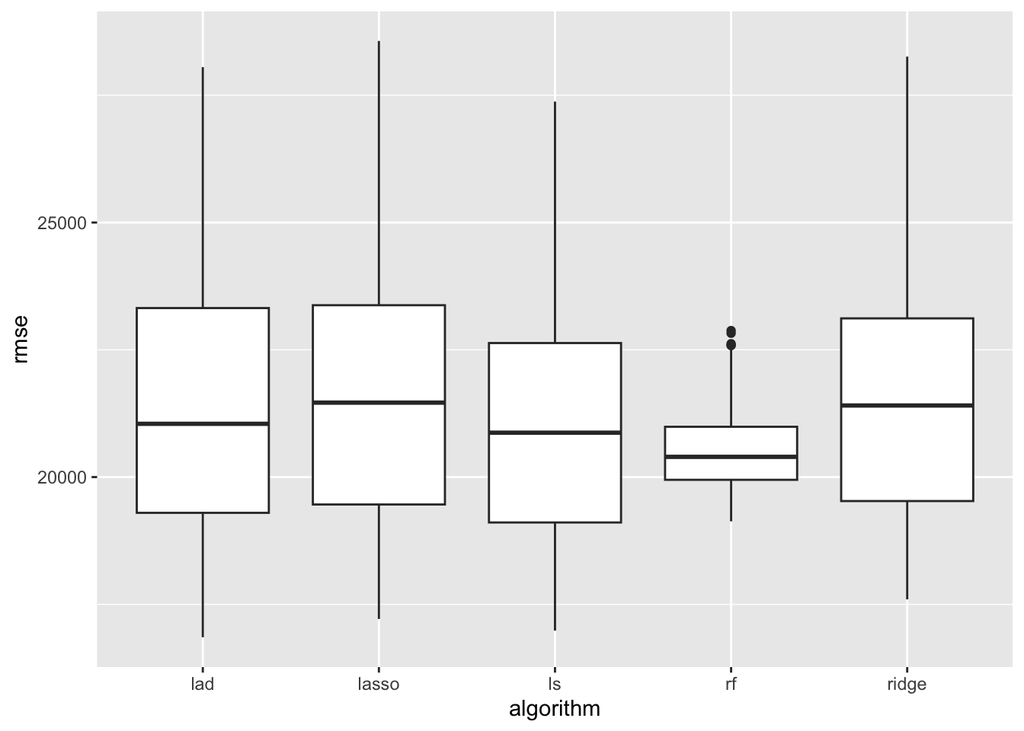

```r
perturbed_jc_performance |>
  ggplot() +
  geom_boxplot(aes(x = algorithm, y = rmse))
```

We can also look at the distributions of the judgment calls grouping by the judgment call options, such as the response transformation:

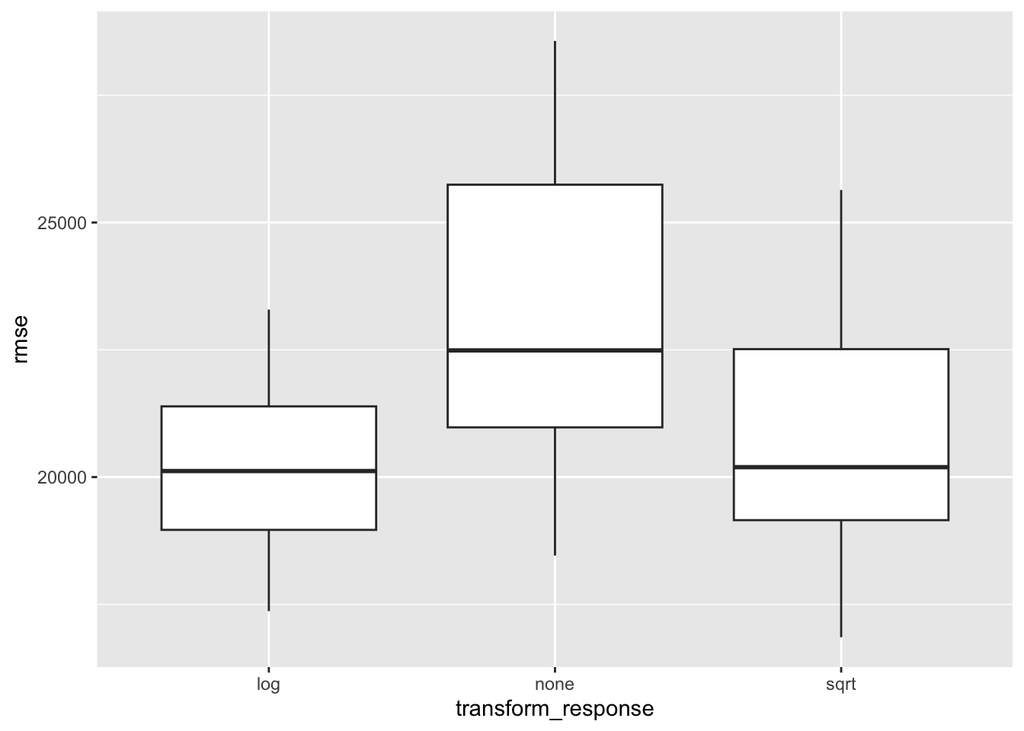

```r
perturbed_jc_performance |>
  ggplot() +
  geom_boxplot(aes(x = transform_response, y = rmse))
```

Note that the log- and square root-transformations are much more accurate in general than the fits with the untransformed response (“none”) (but there are still some fits with the untransformed response that perform quite well).

A histogram below shows the overall distribution:

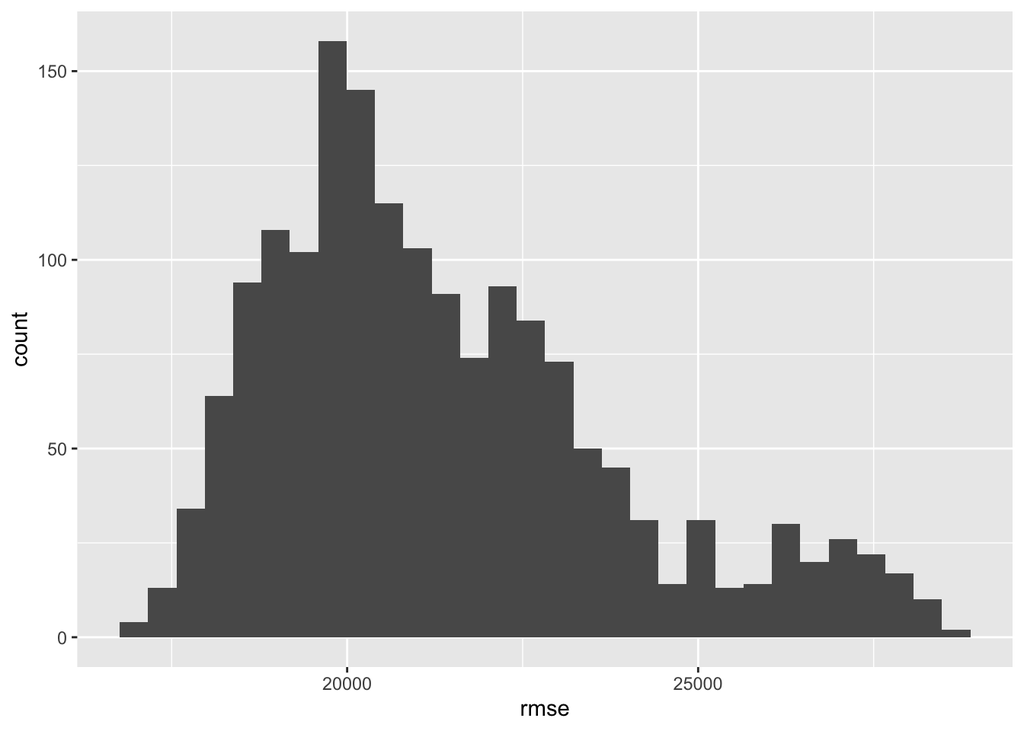

```r
perturbed_jc_performance |>
  ggplot() +
  geom_histogram(aes(x = rmse))
```

When it comes to an ensemble fit, generally if you have a range of performance measures, you will be able to generate more accurate response predictions if you filter to just the best performing fits. Let’s thus conduct a fairly arbitrary **predictability screening test of that requires a validation rMSE set performance in the top 10% of fits**. An ensemble prediction can then be computed by computing the average prediction based on just the top fits.

### 3.1 Test set evaluation

To evaluate the ensemble, let’s compute the ensemble predictions for each of the *test set* data points using just the fits that passed the predictability screening test.

Let’s first identify which fits correspond to a validation set rMSE performance in the top 10% of fits.

```r
# identify the judgment calls and algorithm combinations that correspond
# to the top 10% of fits
predictability_screening_fit_params <- perturbed_jc_performance |>
  # filter to the top 10% of fits in terms of lowest rMSE
  filter(rmse <= quantile(perturbed_jc_performance$rmse, 0.1)) |>
  # arrange in order of rMSE
  arrange(rmse) |>
  select(algorithm, max_identical_thresh, n_neighborhoods,
                impute_missing_categorical, simplify_vars,
                transform_response, cor_feature_selection_threshold,
                convert_categorical)
```

Then, let’s extract the test set predictions:

```r
perturbed_jc_pred_test <- perturbed_jc_pred |>
  ungroup() %>%
  # select the relevant test set predictions for each fit
  select(
    # judgment calls
    max_identical_thresh, n_neighborhoods, impute_missing_categorical,
    simplify_vars, transform_response, cor_feature_selection_threshold,
    convert_categorical,
    # val predictions
    pred_test_ls, pred_test_lad, pred_test_rf,
    pred_test_ridge, pred_test_lasso,
    # val truth
    true_test, pid_test) |>
  # pivot to a long-form version with one column for all the predictions
  pivot_longer(cols = c("pred_test_ls", "pred_test_lad", "pred_test_rf",
                        "pred_test_ridge", "pred_test_lasso"),
               names_to = "algorithm",
               values_to = "pred_test",
               names_prefix = "pred_test_") %>%
  rowwise() %>%
  # undo the log/sqrt transformation where relevant (the predictions are stored
  # in nested list columns)
  mutate(pred_test = case_when(transform_response == "log" ~ list(exp(pred_test)),
                               transform_response == "sqrt" ~ list(pred_test^2),
                               transform_response == "none" ~ list(pred_test))) %>%
  mutate(true_test = case_when(transform_response == "log" ~ list(exp(true_test)),
                               transform_response == "sqrt" ~ list(true_test^2),
                               transform_response == "none" ~ list(true_test))) |>
  # expand the nested list columns
  unnest(c("true_test", "pid_test", "pred_test"))
```

Then to conduct the predictability screening, we can join the `predictability_screening_fits` object:

```r
perturbed_jc_pred_ensemble_test <- perturbed_jc_pred_test |>
  # keep only the rows in perturbed_jc_pred_test that appear in predictability_screening_fits
  semi_join(predictability_screening_fit_params) |>
  # compute the average prediction for each test set house
  group_by(pid_test) |>
  summarise(ensemble_pred_test = mean(pred_test),
            true_test = unique(round(true_test))) |>
  ungroup()
```

[output not shown]

```r
head(perturbed_jc_pred_ensemble_test)
```

```
# A tibble: 6 × 3
   pid_test ensemble_pred_test true_test
      <int>              <dbl>     <dbl>
1 526302110            124076.    124500
2 526350040            113415.    105000
3 526351010            161644.    172000
4 526351100            172810.    157000
5 526353030            262755.    244000
6 526355080            375321.    345000
```

The performance of the ensemble predictions can then be computed using the regular metrics

```r
perturbed_jc_pred_ensemble_test %>%
  # add performance metrics for each perturbed fit
  summarise(cor = cor(true_test, ensemble_pred_test),
            rmse = rmse_vec(true_test, ensemble_pred_test),
            mae = mae_vec(true_test, ensemble_pred_test))
```

```
# A tibble: 1 × 3
    cor   rmse    mae
  <dbl>  <dbl>  <dbl>
1 0.968 18458. 13144.
```

According to all three measures, the ensemble performance on the test set is slightly worse than the single-best fit performance.

## 4 Approach 3: Calibrated PCS perturbation prediction intervals

The process for computing the perturbation prediction intervals (PPIs) is similar to the ensemble prediction process, but instead of averaging the fits that pass the predictability screening test, we compute an interval from them. First, we need to filter to just the top 10% of fits that passed the predictability screening that we conducted for our ensemble fit.

```r
ames_jc_selected <- ames_jc_perturbed %>%
  # do predictability screening (using the ensemble screening results)
  # to make the computation more tractable, just take the top 30 fits instead of
  # the top 10% (which is 168 fits)
  inner_join(predictability_screening_fit_params)
```

[output not shown]

```r
# how many fits pass the predictability screening
nrow(ames_jc_selected)
```

```
[1] 168
```

Next, for each of these top fits, we will retrain them on $L = 10$ bootstrapped versions of the relevant training dataset using the corresponding algorithm for the fit.

First, we will write a function for computing a fit and for generating predictions for each algorithm.

```r
# write a function for fitting each algorithm
computeFit <- function(.algorithm, .data_train) {
  if (.algorithm == "ls") {
    return(lm(sale_price ~ ., .data_train))
  } else if (.algorithm == "lad") {
    return(lad(sale_price ~ ., .data_train, method = "EM"))
  } else if (.algorithm == "rf") {
    return(ranger(sale_price  ~ ., .data_train))
  } else if (.algorithm == "ridge") {
    return(fitRegularizedLs(.data_train, .alpha = 0))
  } else if (.algorithm == "lasso") {
    return(fitRegularizedLs(.data_train, .alpha = 1))
  }
}

# write a function for generating a prediction for each algorithm
predictResponse <- function(fit, .algorithm, .data_train, .data_val) {
  if (.algorithm %in% c("ls", "lad")) {
    return(predict(fit, .data_val))
  } else if (.algorithm == "rf") {
    return(predict(fit, .data_val)$predictions)
  } else if (.algorithm %in% c("ridge", "lasso")) {
    return(predRegularizedLs(fit,
                             .data_train, # this doesn't need to be the bootstrapped training set
                             .data_val))
  }
}
```

In the code below, note that we conduct bootstrapping at the same time as fitting the algorithm. `map_df(1:10, function)` implements the code in the function 10 times, and then concatenates the rows of the data frame output of each iteration. Each iteration can be identified with the `iter` column.

```r
# set up parallel processing so that we can compute the outer map function faster
plan(multisession)
set.seed(1789)
ames_fit_data_jc_perturbed_pred <- future_map_dfr(1:10, function(.iter) {
  ames_jc_selected %>%
    # compute a bootstrapped training sample
    mutate(data_train_perturbed_boot = list(sample_frac(data_train_perturbed, 1,
                                                        replace = TRUE))) %>%
    # then the relevant fits to each bootstrapped jc-perturbed dataset
    mutate(fit = list(computeFit(algorithm, data_train_perturbed_boot)))  %>%
    # validation set predictions
    mutate(pred_val = list(predictResponse(fit, algorithm,
                                           data_train_perturbed,
                                           data_val_perturbed))) %>%
    # test set predictions
    mutate(pred_test = list(predictResponse(fit, algorithm,
                                            data_train_perturbed,
                                            data_test_perturbed))) %>%
    # validation set truth and pid
    mutate(true_val = list(data_val_perturbed$sale_price),
           pid_val = list(data_val_perturbed$pid)) |>
    # test set truth and pid
    mutate(true_test = list(data_test_perturbed$sale_price),
           pid_test = list(data_test_perturbed$pid))
}, .id = "iter", .options = furrr_options(seed = TRUE))
```

We then need to un-transform the response for the fits that involved a transformed response.

```r
# un-transform the log- and sqrt-transformed responses
ames_fit_data_jc_perturbed_pred <- ames_fit_data_jc_perturbed_pred |>
  rowwise() |>
  # undo the transformations
  mutate(pred_val = case_when(transform_response == "log" ~ list(exp(pred_val)),
                              transform_response == "sqrt" ~ list(pred_val^2),
                              transform_response == "none" ~ list(pred_val))) %>%
  mutate(true_val = case_when(transform_response == "log" ~ list(exp(true_val)),
                              transform_response == "sqrt" ~ list(true_val^2),
                              transform_response == "none" ~ list(true_val))) %>%
  mutate(pred_test = case_when(transform_response == "log" ~ list(exp(pred_test)),
                               transform_response == "sqrt" ~ list(pred_test^2),
                               transform_response == "none" ~ list(pred_test))) %>%
  mutate(true_test = case_when(transform_response == "log" ~ list(exp(true_test)),
                               transform_response == "sqrt" ~ list(true_test^2),
                               transform_response == "none" ~ list(true_test)))
```

And we can then compute the uncalibrated intervals for the validation data:

```r
# compute the uncalibrated intervals for the validation data
ames_val_pred_intervals <- ames_fit_data_jc_perturbed_pred |>
  dplyr::select(pid_val, true_val, pred_val) |>
  unnest(cols = c(pid_val, true_val, pred_val)) %>%
  group_by(pid_val) |>
  # compute the 5th and 95th quantile predictions
  summarise(true_val = unique(round(true_val)),
            median_pred_val = median(pred_val),
            q05 = quantile(pred_val, 0.05),
            q95 = quantile(pred_val, 0.95))
```

### 4.1 Multiplicative calibration

We can compute the coverage of the intervals:

```r
val_coverage <- ames_val_pred_intervals |>
  mutate(covered = (true_val <= q95) & (true_val >= q05)) %>%
  summarise(coverage = mean(covered)) %>%
  pull(coverage)
val_coverage
```

```
[1] 0.5974843
```

This is unfortunately far lower than the 90% coverage that we were aiming for! But that’s ok, because we can compute *calibrated* intervals based on the median prediction, of the form:

$$[\textrm{median} - c (\textrm{median} - q_{0.05}), ~~\textrm{median} + c (q_{0.95} - \textrm{median})]$$
where the constant $\gamma$ is chosen so that the calibrated interval will have a coverage of 0.9.

```r
const <- 2.04
ames_val_pred_intervals <- ames_val_pred_intervals %>%
  mutate(q05_calibrated = median_pred_val - const * (median_pred_val - q05),
         q95_calibrated = median_pred_val + const * (q95 - median_pred_val))
```

It seems like a constant value of $\gamma$ = 2.04 yields calibrated intervals with coverage of 0.9, as shown below:

```r
val_calibrated_coverage <- ames_val_pred_intervals |>
  mutate(covered = (true_val <= q95_calibrated) & (true_val >= q05_calibrated)) %>%
  summarise(coverage = mean(covered)) %>%
  pull(coverage)
val_calibrated_coverage
```

```
[1] 0.8946541
```

We can visualize the calibrated intervals using a prediction stability plot:

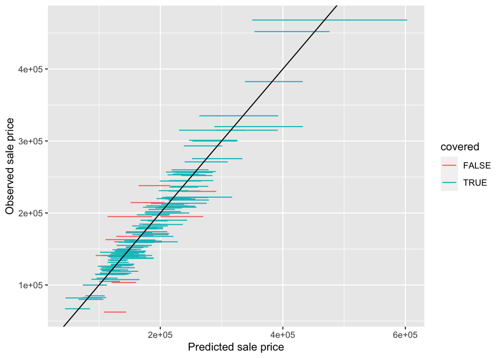

```r
set.seed(3864)
sample_val_pid <- sample(ames_val_preprocessed$pid, 150)

ames_val_pred_intervals %>%
  filter(pid_val %in% sample_val_pid) %>%
  mutate(covered = (true_val <= q95_calibrated) & (true_val >= q05_calibrated)) %>%
  ggplot() +
  geom_segment(aes(x = q05_calibrated, xend = q95_calibrated,
                   y = true_val, yend = true_val, col = covered)) +
  geom_abline(intercept = 0, slope = 1) +
  labs(x = "Predicted sale price", y = "Observed sale price")
```

### 4.2 Test set evaluation

Finally, using our calibration constant that we computed using the validation set, and we can generate calibrated prediction perturbation intervals for our test set houses and compute the coverage of the intervals.

Let’s compute the intervals for the test set observations as follows (this is using the same `gamma` value that we used before — it is important *not* to change this value)

```r
ames_test_pred_intervals <- ames_fit_data_jc_perturbed_pred |>
  dplyr::select(pid_test, true_test, pred_test) |>
  unnest(cols = c(pid_test, true_test, pred_test)) %>%
  group_by(pid_test) |>
  # compute the 5th and 95th quantile predictions
  summarise(true_test = unique(round(true_test)),
            median_pred_test = median(pred_test),
            q05 = quantile(pred_test, 0.05),
            q95 = quantile(pred_test, 0.95),
            q05_calibrated = median_pred_test - const * (median_pred_test - q05),
            q95_calibrated = median_pred_test + const * (q95 - median_pred_test))
```

And we can compute the coverage of these intervals using the following code:

```r
test_calibrated_coverage <- ames_test_pred_intervals |>
  mutate(covered = (true_test <= q95_calibrated) & (true_test >= q05_calibrated)) %>%
  summarise(coverage = mean(covered)) %>%
  pull(coverage)

test_calibrated_coverage
```

```
[1] 0.8787402
```

The test set coverage is fairly close to 90%, which is what we were hoping to see.

### 4.3 [Chapter 14, Exercise 17] Additive calibration

You may want to complete the Chapter 14 additive calibration exercise (exercise 17) here.

## 5 [Chapter 14, Exercise 19] Post-hoc evaluation

You may want to complete the post-hoc evaluation exercise here.